Home > Archives > Ggplot2图形的格式化调整示例

# Ggplot2图形的格式化调整示例

Publish: March 3, 2015

一旦你完成了作图，就需要进行一些图形的可视化调整了，这个教程将会一步步教你如何来进行图形格式的调整，我们先看一个简单的代码。

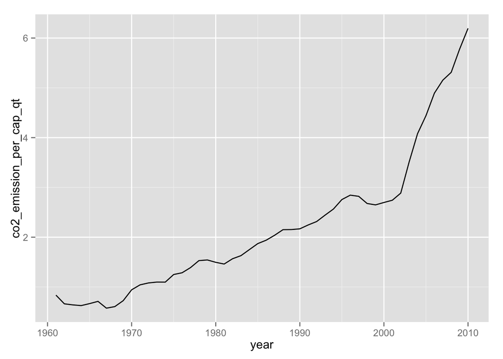

```r
library(ggplot2)
df.china_co2 <- read.csv(url("http://www.sharpsightlabs.com/wp-content/uploads/2015/01/china_co2_1961_to_2010_data.txt"))

ggplot(data=df.china_co2, aes(x=year,y=co2_emission_per_cap_qt)) +
  geom_line()
```

如图，可以通过上述代码来画简单的图形，进行一些数据的探索工作（这个阶段，需要尽量简单和快速），但如果说要把结果呈现给用户，那么这样的图形就太简单了。

人类喜欢漂亮的东西，图形越漂亮，就会有更多更重要的人关注，那么如何把简单的图形变得更加漂亮呢？

### 增加表格和轴的标题

| 功能 | 函数 | 解释 |
| --- | --- | --- |
| 增加表标题 | ggtitle() |  |
| 轴标题 | labs() | 其中参数“x=”,“y=”输入x轴和y轴的标题 |

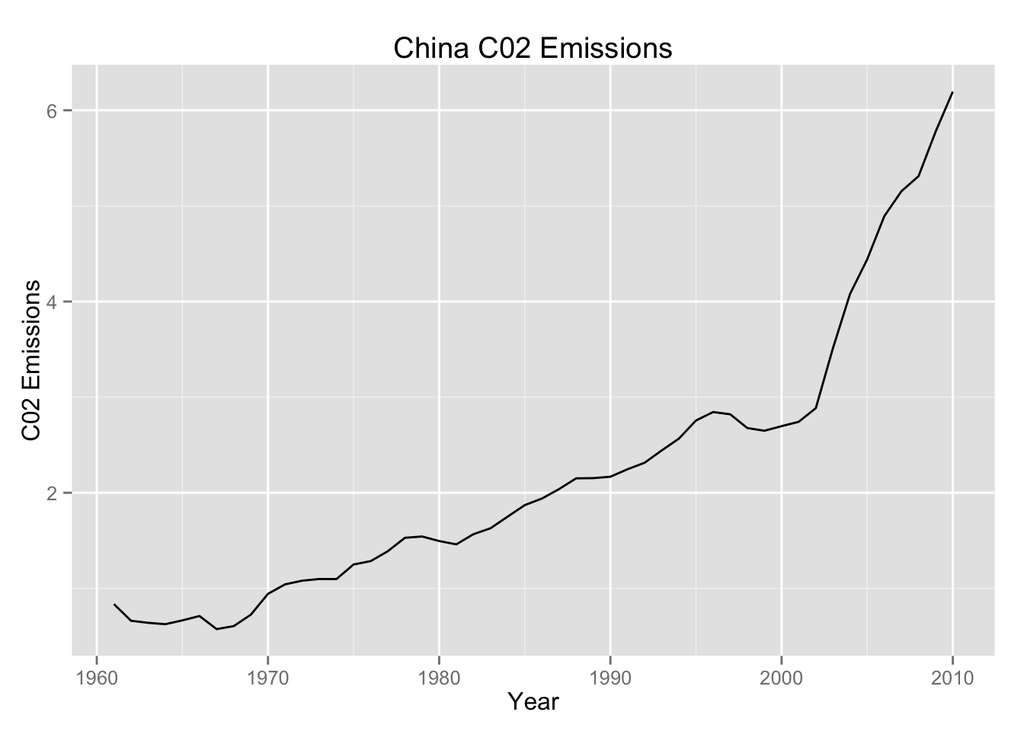

```r
ggplot(data=df.china_co2, aes(x=year, y=co2_emission_per_cap_qt)) +
  geom_line() +
  ggtitle("China C02 Emissions") +
  labs(x="Year",y="C02 Emissions")
```

### 增加主题—theme()函数

theme()函数是，专门用来对非数据元素，进行格式化修改的一个函数，它几乎可以修改任何非数据元素，参数调用指定待修改的元素。

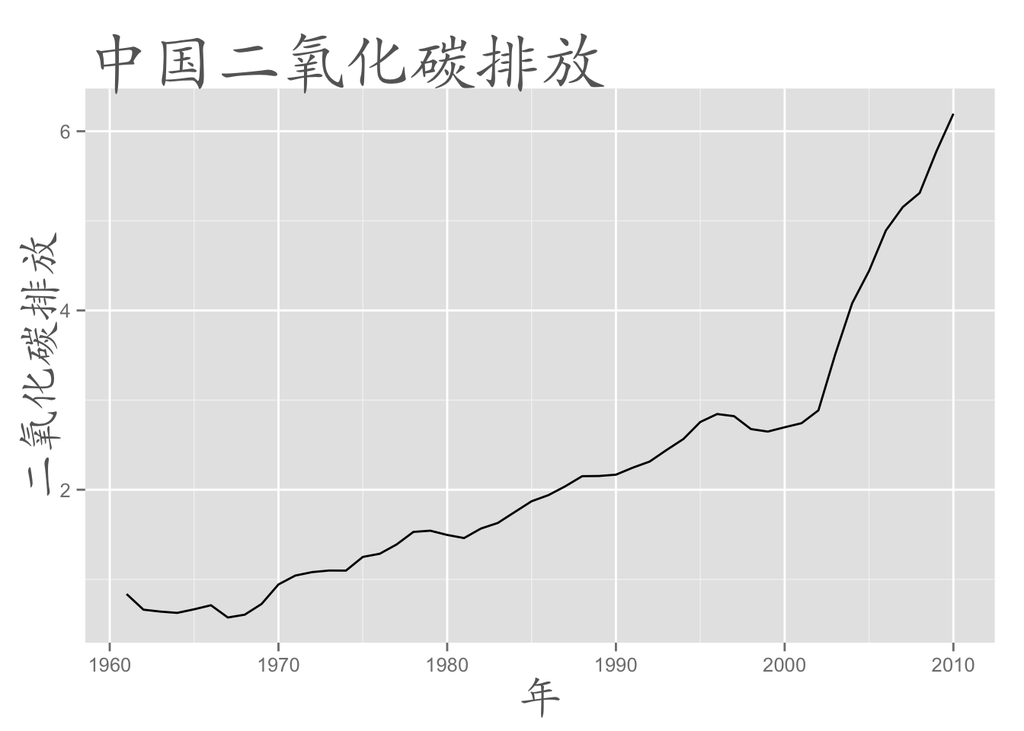

```r
ggplot(data=df.china_co2, aes(x=year, y=co2_emission_per_cap_qt)) +
  geom_line() +
  ggtitle("中国二氧化碳排放") +
  labs(x="年",y="二氧化碳排放")+theme(plot.title=element_text(family='STKaiti',color="#666666",face='bold',size=32,hjust=0))+theme(axis.title=element_text(family='STKaiti',color="#666666",face='bold',size=22))
```

上述分别更改了图形的题目和轴的题目，并对字体、粗细和大小进行了一些调整。一次调用theme(),调整了标题(plot.title)，另一次theme()调整了轴的标题(axix.title)。

| 主题元素 | 解释 |
| --- | --- |
| plot.title | 图形标题 |
| axis.title | 轴标题 |
| axis.title.x | x轴标题 |
| axis.title.y | y轴标题 |

具体修改这些主题元素，因为以上几种元素都是文本元素，ggplot2使用element_text()函数进行文本格式修改。所以具体的对于text元素来说，我们用element_text()函数进行参数的修改。

| 参数 | 解释 |
| --- | --- |
| size= | 字体大小 |
| face= | 粗体或者斜体bold/italic |
| color= | 字体颜色 |
| hjust= | 水平位置 |
| angle= | 角度 |

#### 元素的继承关系

注意plot.title和axis.title都是title，如果我们更改title，那么我们也更改了plot.title和axis.title，比如。

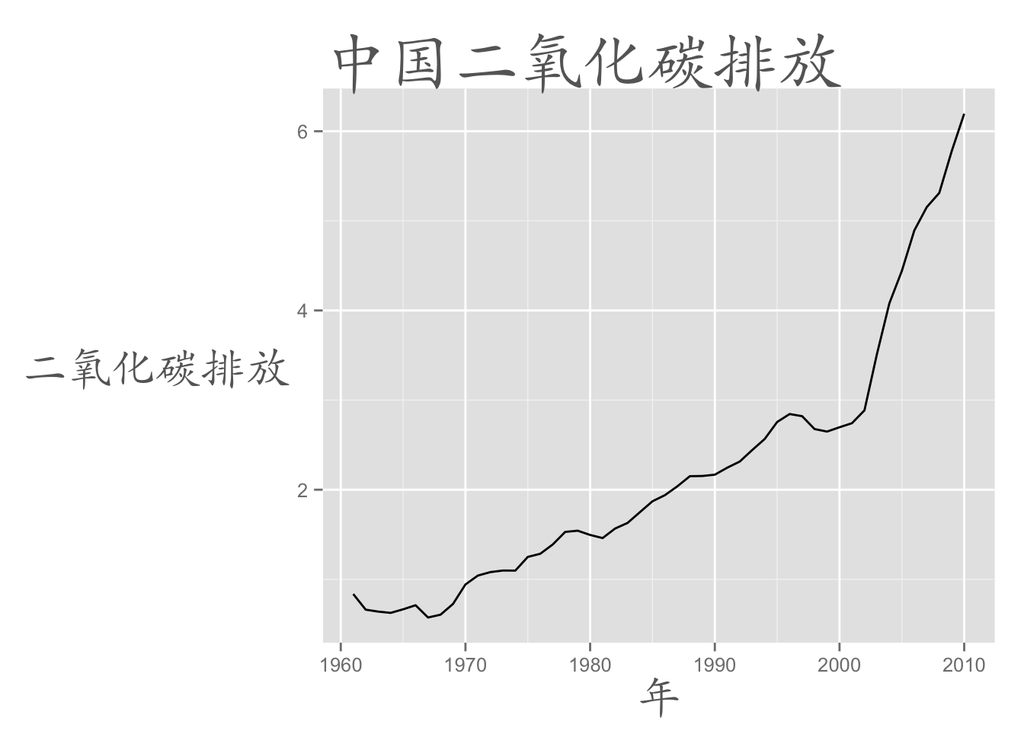

```r
ggplot(data=df.china_co2, aes(x=year, y=co2_emission_per_cap_qt)) +
  geom_line() +
  ggtitle("中国二氧化碳排放") +
  labs(x="年",y="二氧化碳排放")+theme(plot.title=element_text(family='STKaiti',color="#666666",face='bold',size=32,hjust=0))+theme(axis.title=element_text(family='STKaiti',color="#666666",face='bold',size=22)) +theme(axis.title.y=element_text(angle=0))
```

在这里，我们更改了x与y轴的标题格式，又通过调用axis.title.y更改了y轴的标题的角度(angle=0)。

如上所述，ggplot确实有一定的学习曲线，但是一旦你掌握了它的系统，你作图的能力会大幅增加，实际上，掌握ggplot2主题系统能够大幅加速你的格式修改工作。

### 总结

ggplot中有一套theme系统，它的格式修改包含以下几个步骤：

1. theme()函数进行格式修改
2. 函数参数为修改的主题元素名称
3. element_xyz()修改具体元素，xyz是元素类型
4. element_xyz()参数的值，对应地具体元素的格式

希望本文能够帮助到您！

声明: 本文采用 [BY-NC-SA](http://creativecommons.org/licenses/by-nc-sa/3.0/) 授权。转载请注明转自: tegulia

« Ggplot2散点图

Ggplot2直方图 »